# Lecture 16b:ANCOVA in tidyverse

## 7.1 QQ plot of the residuals to assess how well the residuals compare with an ideal normal distribution

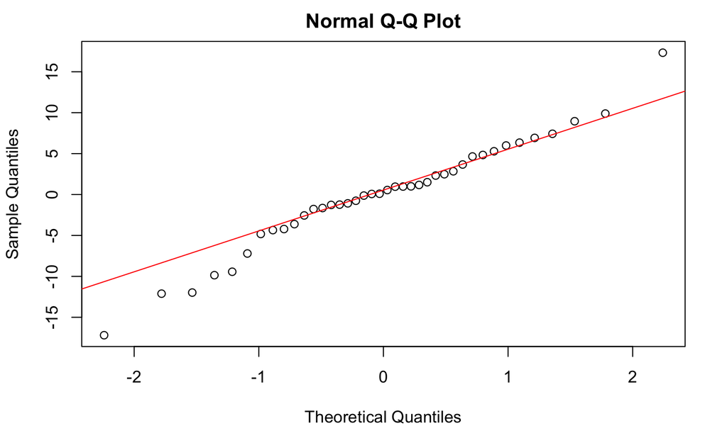

```r
qqnorm(rsd)
qqline(rsd,col="red")
```

# 8 Check for a trend in the residuals with the X axis variable

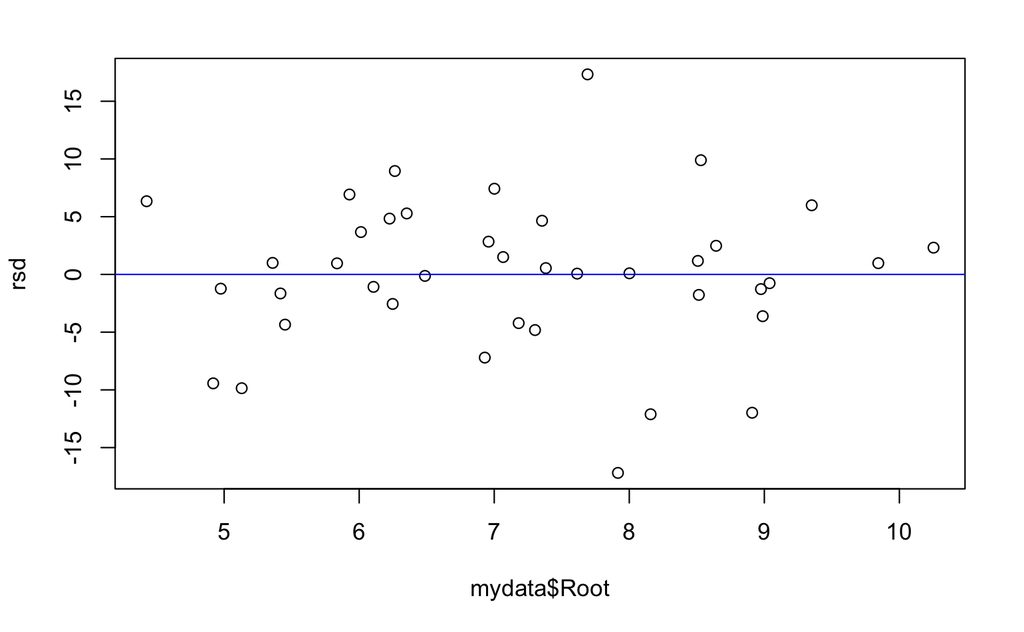

```r
plot(mydata$Root,rsd)
abline(0,0,col="blue")
```

Any pattern among the differences between model and observed value indicates a failure of the model to adequately represent some aspect of the relationship within the sampled data.

# 9 Save your data

(only if you want, and this chunk is not evaluated in this markdown)

The “list=” command tells us which variables we want to save The “file=” option tells us what file to save the data to

```r
save( list=ls(), file="grazing_data.rdata" )
```